# Risk Factor Analysis

## Outcome Variable

**Outcome Variable:** stunted

## Predictor Variables

**Intervention Variable:** earlybf

**Adjustment Set:**

- arm
- sex
- W_mage
- meducyrs
- feducyrs
- hhwealth_quart
- hfoodsec
- W_mhtcm
- vagbrth
- W_birthwt
- W_birthlen
- W_nrooms
- W_nchldlt5
- brthmon
- W_parity
- impfloor
- impsan
- safeh20
- delta_W_mage
- delta_meducyrs
- delta_feducyrs
- delta_hhwealth_quart
- delta_hfoodsec
- delta_W_mhtcm
- delta_vagbrth
- delta_W_birthwt
- delta_W_birthlen
- delta_W_nrooms
- delta_W_nchldlt5
- delta_brthmon
- delta_W_parity
- delta_impfloor
- delta_impsan
- delta_safeh20

## Stratifying Variables

The analysis was stratified on these variable(s):

- agecat
- studyid
- country

## Data Summary

| agecat | studyid | country | earlybf | stunted | n_cell | n |
| --- | --- | --- | --- | --- | --- | --- |
| Birth | ki0047075b-MAL-ED | BANGLADESH | 0 | 0 | 75 | 256 |
| Birth | ki0047075b-MAL-ED | BANGLADESH | 0 | 1 | 22 | 256 |
| Birth | ki0047075b-MAL-ED | BANGLADESH | 1 | 0 | 134 | 256 |
| Birth | ki0047075b-MAL-ED | BANGLADESH | 1 | 1 | 25 | 256 |
| 6 months | ki0047075b-MAL-ED | BANGLADESH | 0 | 0 | 72 | 240 |
| 6 months | ki0047075b-MAL-ED | BANGLADESH | 0 | 1 | 21 | 240 |
| 6 months | ki0047075b-MAL-ED | BANGLADESH | 1 | 0 | 123 | 240 |
| 6 months | ki0047075b-MAL-ED | BANGLADESH | 1 | 1 | 24 | 240 |
| 24 months | ki0047075b-MAL-ED | BANGLADESH | 0 | 0 | 47 | 211 |
| 24 months | ki0047075b-MAL-ED | BANGLADESH | 0 | 1 | 36 | 211 |
| 24 months | ki0047075b-MAL-ED | BANGLADESH | 1 | 0 | 67 | 211 |
| 24 months | ki0047075b-MAL-ED | BANGLADESH | 1 | 1 | 61 | 211 |
| Birth | ki0047075b-MAL-ED | BRAZIL | 0 | 0 | 94 | 191 |
| Birth | ki0047075b-MAL-ED | BRAZIL | 0 | 1 | 14 | 191 |
| Birth | ki0047075b-MAL-ED | BRAZIL | 1 | 0 | 76 | 191 |
| Birth | ki0047075b-MAL-ED | BRAZIL | 1 | 1 | 7 | 191 |
| 6 months | ki0047075b-MAL-ED | BRAZIL | 0 | 0 | 110 | 209 |
| 6 months | ki0047075b-MAL-ED | BRAZIL | 0 | 1 | 4 | 209 |
| 6 months | ki0047075b-MAL-ED | BRAZIL | 1 | 0 | 93 | 209 |
| 6 months | ki0047075b-MAL-ED | BRAZIL | 1 | 1 | 2 | 209 |
| 24 months | ki0047075b-MAL-ED | BRAZIL | 0 | 0 | 85 | 169 |
| 24 months | ki0047075b-MAL-ED | BRAZIL | 0 | 1 | 4 | 169 |
| 24 months | ki0047075b-MAL-ED | BRAZIL | 1 | 0 | 78 | 169 |
| 24 months | ki0047075b-MAL-ED | BRAZIL | 1 | 1 | 2 | 169 |
| Birth | ki0047075b-MAL-ED | INDIA | 0 | 0 | 66 | 205 |
| Birth | ki0047075b-MAL-ED | INDIA | 0 | 1 | 15 | 205 |
| Birth | ki0047075b-MAL-ED | INDIA | 1 | 0 | 106 | 205 |
| Birth | ki0047075b-MAL-ED | INDIA | 1 | 1 | 18 | 205 |
| 6 months | ki0047075b-MAL-ED | INDIA | 0 | 0 | 76 | 236 |
| 6 months | ki0047075b-MAL-ED | INDIA | 0 | 1 | 20 | 236 |

[output cut: 126 more lines]

The following strata were considered:

- agecat: 24 months, studyid: ki0047075b-MAL-ED, country: BANGLADESH
- agecat: 24 months, studyid: ki0047075b-MAL-ED, country: BRAZIL
- agecat: 24 months, studyid: ki0047075b-MAL-ED, country: INDIA
- agecat: 24 months, studyid: ki0047075b-MAL-ED, country: NEPAL
- agecat: 24 months, studyid: ki0047075b-MAL-ED, country: PERU
- agecat: 24 months, studyid: ki0047075b-MAL-ED, country: SOUTH AFRICA
- agecat: 24 months, studyid: ki0047075b-MAL-ED, country: TANZANIA, UNITED REPUBLIC OF
- agecat: 24 months, studyid: ki1017093c-NIH-Crypto, country: BANGLADESH
- agecat: 24 months, studyid: ki1113344-GMS-Nepal, country: NEPAL
- agecat: 24 months, studyid: ki1126311-ZVITAMBO, country: ZIMBABWE
- agecat: 24 months, studyid: kiGH5241-JiVitA-3, country: BANGLADESH
- agecat: 24 months, studyid: kiGH5241-JiVitA-4, country: BANGLADESH
- agecat: 6 months, studyid: ki0047075b-MAL-ED, country: BANGLADESH
- agecat: 6 months, studyid: ki0047075b-MAL-ED, country: BRAZIL
- agecat: 6 months, studyid: ki0047075b-MAL-ED, country: INDIA
- agecat: 6 months, studyid: ki0047075b-MAL-ED, country: NEPAL
- agecat: 6 months, studyid: ki0047075b-MAL-ED, country: PERU
- agecat: 6 months, studyid: ki0047075b-MAL-ED, country: SOUTH AFRICA
- agecat: 6 months, studyid: ki0047075b-MAL-ED, country: TANZANIA, UNITED REPUBLIC OF
- agecat: 6 months, studyid: ki1000109-EE, country: PAKISTAN
- agecat: 6 months, studyid: ki1000304b-SAS-CompFeed, country: INDIA
- agecat: 6 months, studyid: ki1017093c-NIH-Crypto, country: BANGLADESH
- agecat: 6 months, studyid: ki1113344-GMS-Nepal, country: NEPAL
- agecat: 6 months, studyid: ki1126311-ZVITAMBO, country: ZIMBABWE
- agecat: 6 months, studyid: kiGH5241-JiVitA-3, country: BANGLADESH
- agecat: 6 months, studyid: kiGH5241-JiVitA-4, country: BANGLADESH
- agecat: Birth, studyid: ki0047075b-MAL-ED, country: BANGLADESH
- agecat: Birth, studyid: ki0047075b-MAL-ED, country: BRAZIL
- agecat: Birth, studyid: ki0047075b-MAL-ED, country: INDIA
- agecat: Birth, studyid: ki0047075b-MAL-ED, country: NEPAL
- agecat: Birth, studyid: ki0047075b-MAL-ED, country: PERU
- agecat: Birth, studyid: ki0047075b-MAL-ED, country: SOUTH AFRICA
- agecat: Birth, studyid: ki0047075b-MAL-ED, country: TANZANIA, UNITED REPUBLIC OF
- agecat: Birth, studyid: ki1000109-EE, country: PAKISTAN
- agecat: Birth, studyid: ki1000304b-SAS-CompFeed, country: INDIA
- agecat: Birth, studyid: ki1017093c-NIH-Crypto, country: BANGLADESH
- agecat: Birth, studyid: ki1126311-ZVITAMBO, country: ZIMBABWE
- agecat: Birth, studyid: kiGH5241-JiVitA-3, country: BANGLADESH
- agecat: Birth, studyid: kiGH5241-JiVitA-4, country: BANGLADESH

### Dropped Strata

Some strata were dropped due to rare outcomes:

- agecat: 6 months, studyid: ki0047075b-MAL-ED, country: BRAZIL
- agecat: 24 months, studyid: ki0047075b-MAL-ED, country: BRAZIL
- agecat: 6 months, studyid: ki0047075b-MAL-ED, country: NEPAL
- agecat: Birth, studyid: ki0047075b-MAL-ED, country: TANZANIA, UNITED REPUBLIC OF
- agecat: Birth, studyid: ki1000109-EE, country: PAKISTAN
- agecat: Birth, studyid: ki1000304b-SAS-CompFeed, country: INDIA
- agecat: Birth, studyid: ki1017093c-NIH-Crypto, country: BANGLADESH
- agecat: 24 months, studyid: kiGH5241-JiVitA-3, country: BANGLADESH

## Methods Detail

We’re interested in the causal parameters $E[Y_a]$ for all values of $a \in \mathcal{A}$. These parameters represent the mean outcome if, possibly contrary to fact, we intervened to set all units to have $A=a$. Under the randomization and positivity assumptions, these are identified by the statistical parameters $\psi_a=E_W[E_{Y|A,W}(Y|A=a,W)]$. In addition, we’re interested in the mean of $Y$, $E[Y]$ under no intervention (the observed mean). We will estimate these parameters by using SuperLearner to fit the relevant likelihood factors – $E_{Y|A,W}(Y|A=a,W)$ and $p(A=a|W)$, and then updating our likelihood fit using a joint TMLE.

For unadjusted analyses ($W=\{\}$), initial likelihoods were estimated using Lrnr_glm to estimate the simple $E(Y|A)$ and Lrnr_mean to estimate $p(A)$. For adjusted analyses, a small library containing Lrnr_glmnet, Lrnr_xgboost, and Lrnr_mean was used.

Having estimated these parameters, we will then use the delta method to estimate relative risks and attributable risks relative to a prespecified baseline level of $A$.

# Results Detail

## Results Plots

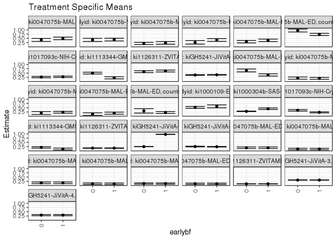

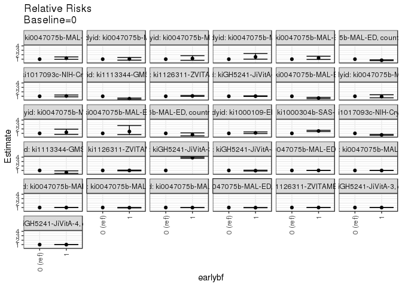

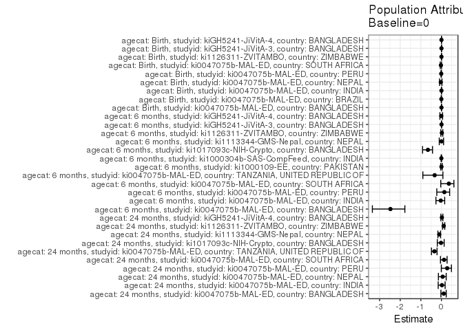

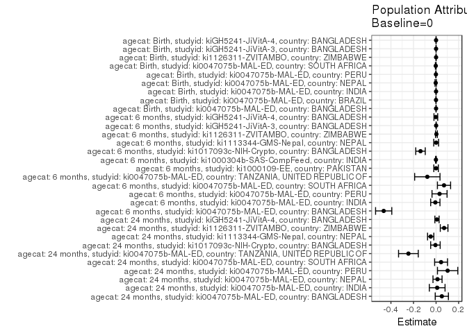

## Results Table

### Parameter: TSM

| agecat | studyid | country | intervention_level | baseline_level | estimate | ci_lower | ci_upper |
| --- | --- | --- | --- | --- | --- | --- | --- |
| Birth | ki0047075b-MAL-ED | BANGLADESH | 0 | NA | 0.1836186 | 0.1360953 | 0.2311420 |
| Birth | ki0047075b-MAL-ED | BANGLADESH | 1 | NA | 0.1835761 | 0.1360618 | 0.2310904 |
| Birth | ki0047075b-MAL-ED | BRAZIL | 0 | NA | 0.1105172 | 0.0659257 | 0.1551087 |
| Birth | ki0047075b-MAL-ED | BRAZIL | 1 | NA | 0.1090104 | 0.0649176 | 0.1531032 |
| Birth | ki0047075b-MAL-ED | INDIA | 0 | NA | 0.1610801 | 0.1106202 | 0.2115400 |
| Birth | ki0047075b-MAL-ED | INDIA | 1 | NA | 0.1608901 | 0.1104836 | 0.2112965 |
| Birth | ki0047075b-MAL-ED | NEPAL | 0 | NA | 0.1073759 | 0.0613935 | 0.1533583 |
| Birth | ki0047075b-MAL-ED | NEPAL | 1 | NA | 0.1034792 | 0.0580083 | 0.1489502 |
| Birth | ki0047075b-MAL-ED | PERU | 0 | NA | 0.1197723 | 0.0822038 | 0.1573408 |
| Birth | ki0047075b-MAL-ED | PERU | 1 | NA | 0.1176999 | 0.0804632 | 0.1549366 |
| Birth | ki0047075b-MAL-ED | SOUTH AFRICA | 0 | NA | 0.1080122 | 0.0695146 | 0.1465098 |
| Birth | ki0047075b-MAL-ED | SOUTH AFRICA | 1 | NA | 0.1049896 | 0.0667347 | 0.1432445 |
| Birth | ki1126311-ZVITAMBO | ZIMBABWE | 0 | NA | 0.1029228 | 0.0975571 | 0.1082886 |
| Birth | ki1126311-ZVITAMBO | ZIMBABWE | 1 | NA | 0.1029080 | 0.0975430 | 0.1082730 |
| Birth | kiGH5241-JiVitA-3 | BANGLADESH | 0 | NA | 0.3232676 | 0.3156078 | 0.3309275 |
| Birth | kiGH5241-JiVitA-3 | BANGLADESH | 1 | NA | 0.3223945 | 0.3147556 | 0.3300333 |
| Birth | kiGH5241-JiVitA-4 | BANGLADESH | 0 | NA | 0.3005288 | 0.2649548 | 0.3361027 |
| Birth | kiGH5241-JiVitA-4 | BANGLADESH | 1 | NA | 0.3004671 | 0.2649008 | 0.3360333 |
| 6 months | ki0047075b-MAL-ED | BANGLADESH | 0 | NA | 0.6516907 | 0.5674976 | 0.7358838 |
| 6 months | ki0047075b-MAL-ED | BANGLADESH | 1 | NA | 0.3860262 | 0.3188986 | 0.4531538 |
| 6 months | ki0047075b-MAL-ED | INDIA | 0 | NA | 0.2016104 | 0.1364267 | 0.2667941 |
| 6 months | ki0047075b-MAL-ED | INDIA | 1 | NA | 0.1890434 | 0.1316736 | 0.2464132 |
| 6 months | ki0047075b-MAL-ED | PERU | 0 | NA | 0.1890626 | 0.1062190 | 0.2719062 |
| 6 months | ki0047075b-MAL-ED | PERU | 1 | NA | 0.2323286 | 0.1781965 | 0.2864606 |
| 6 months | ki0047075b-MAL-ED | SOUTH AFRICA | 0 | NA | 0.1255935 | 0.0512075 | 0.1999794 |
| 6 months | ki0047075b-MAL-ED | SOUTH AFRICA | 1 | NA | 0.1782635 | 0.1182623 | 0.2382647 |
| 6 months | ki0047075b-MAL-ED | TANZANIA, UNITED REPUBLIC OF | 0 | NA | 0.3123675 | 0.1831158 | 0.4416191 |
| 6 months | ki0047075b-MAL-ED | TANZANIA, UNITED REPUBLIC OF | 1 | NA | 0.2173137 | 0.1622344 | 0.2723930 |
| 6 months | ki1000109-EE | PAKISTAN | 0 | NA | 0.5188440 | 0.4646728 | 0.5730152 |
| 6 months | ki1000109-EE | PAKISTAN | 1 | NA | 0.5801102 | 0.4935542 | 0.6666663 |
| 6 months | ki1000304b-SAS-CompFeed | INDIA | 0 | NA | 0.2857433 | 0.2694778 | 0.3020088 |
| 6 months | ki1000304b-SAS-CompFeed | INDIA | 1 | NA | 0.4391652 | 0.3923285 | 0.4860018 |
| 6 months | ki1017093c-NIH-Crypto | BANGLADESH | 0 | NA | 0.3477079 | 0.3020637 | 0.3933520 |
| 6 months | ki1017093c-NIH-Crypto | BANGLADESH | 1 | NA | 0.2276284 | 0.1954651 | 0.2597917 |
| 6 months | ki1113344-GMS-Nepal | NEPAL | 0 | NA | 0.2051923 | 0.1634366 | 0.2469479 |
| 6 months | ki1113344-GMS-Nepal | NEPAL | 1 | NA | 0.1119500 | 0.0603481 | 0.1635520 |
| 6 months | ki1126311-ZVITAMBO | ZIMBABWE | 0 | NA | 0.1643902 | 0.1529365 | 0.1758440 |
| 6 months | ki1126311-ZVITAMBO | ZIMBABWE | 1 | NA | 0.1630698 | 0.1524155 | 0.1737241 |
| 6 months | kiGH5241-JiVitA-3 | BANGLADESH | 0 | NA | 0.2508701 | 0.2427364 | 0.2590038 |
| 6 months | kiGH5241-JiVitA-3 | BANGLADESH | 1 | NA | 0.9712017 | 0.9624793 | 0.9799241 |
| 6 months | kiGH5241-JiVitA-4 | BANGLADESH | 0 | NA | 0.2546510 | 0.2329598 | 0.2763422 |
| 6 months | kiGH5241-JiVitA-4 | BANGLADESH | 1 | NA | 0.2434707 | 0.2268760 | 0.2600655 |
| 24 months | ki0047075b-MAL-ED | BANGLADESH | 0 | NA | 0.4086870 | 0.3198258 | 0.4975482 |
| 24 months | ki0047075b-MAL-ED | BANGLADESH | 1 | NA | 0.4941688 | 0.4186539 | 0.5696838 |
| 24 months | ki0047075b-MAL-ED | INDIA | 0 | NA | 0.4086081 | 0.3143406 | 0.5028757 |
| 24 months | ki0047075b-MAL-ED | INDIA | 1 | NA | 0.4251262 | 0.3442892 | 0.5059632 |
| 24 months | ki0047075b-MAL-ED | NEPAL | 0 | NA | 0.2021232 | 0.1357999 | 0.2684464 |
| 24 months | ki0047075b-MAL-ED | NEPAL | 1 | NA | 0.2333486 | 0.1556090 | 0.3110882 |
| 24 months | ki0047075b-MAL-ED | PERU | 0 | NA | 0.2656398 | 0.1636297 | 0.3676500 |
| 24 months | ki0047075b-MAL-ED | PERU | 1 | NA | 0.4022929 | 0.3243637 | 0.4802221 |
| 24 months | ki0047075b-MAL-ED | SOUTH AFRICA | 0 | NA | 0.3045555 | 0.2319803 | 0.3771307 |
| 24 months | ki0047075b-MAL-ED | SOUTH AFRICA | 1 | NA | 0.3815711 | 0.3115472 | 0.4515950 |
| 24 months | ki0047075b-MAL-ED | TANZANIA, UNITED REPUBLIC OF | 0 | NA | 0.9600492 | 0.8724255 | 1.0476729 |
| 24 months | ki0047075b-MAL-ED | TANZANIA, UNITED REPUBLIC OF | 1 | NA | 0.7314198 | 0.6665766 | 0.7962629 |
| 24 months | ki1017093c-NIH-Crypto | BANGLADESH | 0 | NA | 0.2626409 | 0.2210743 | 0.3042076 |
| 24 months | ki1017093c-NIH-Crypto | BANGLADESH | 1 | NA | 0.2785215 | 0.2384122 | 0.3186308 |
| 24 months | ki1113344-GMS-Nepal | NEPAL | 0 | NA | 0.4937866 | 0.4410271 | 0.5465461 |
| 24 months | ki1113344-GMS-Nepal | NEPAL | 1 | NA | 0.2190766 | 0.1571645 | 0.2809888 |
| 24 months | ki1126311-ZVITAMBO | ZIMBABWE | 0 | NA | 0.5778582 | 0.5216884 | 0.6340281 |
| 24 months | ki1126311-ZVITAMBO | ZIMBABWE | 1 | NA | 0.6185494 | 0.5650763 | 0.6720224 |
| 24 months | kiGH5241-JiVitA-4 | BANGLADESH | 0 | NA | 0.3841679 | 0.3597318 | 0.4086040 |
| 24 months | kiGH5241-JiVitA-4 | BANGLADESH | 1 | NA | 0.3939865 | 0.3736788 | 0.4142943 |

### Parameter: E(Y)

| agecat | studyid | country | intervention_level | baseline_level | estimate | ci_lower | ci_upper |
| --- | --- | --- | --- | --- | --- | --- | --- |
| Birth | ki0047075b-MAL-ED | BANGLADESH | NA | NA | 0.1835938 | 0.1360755 | 0.2311120 |
| Birth | ki0047075b-MAL-ED | BRAZIL | NA | NA | 0.1099476 | 0.0654669 | 0.1544284 |
| Birth | ki0047075b-MAL-ED | INDIA | NA | NA | 0.1609756 | 0.1105443 | 0.2114069 |
| Birth | ki0047075b-MAL-ED | NEPAL | NA | NA | 0.1040462 | 0.0584174 | 0.1496751 |
| Birth | ki0047075b-MAL-ED | PERU | NA | NA | 0.1184669 | 0.0810142 | 0.1559196 |
| Birth | ki0047075b-MAL-ED | SOUTH AFRICA | NA | NA | 0.1052632 | 0.0669131 | 0.1436132 |
| Birth | ki1126311-ZVITAMBO | ZIMBABWE | NA | NA | 0.1029304 | 0.0975643 | 0.1082966 |
| Birth | kiGH5241-JiVitA-3 | BANGLADESH | NA | NA | 0.3232690 | 0.3156091 | 0.3309289 |
| Birth | kiGH5241-JiVitA-4 | BANGLADESH | NA | NA | 0.3004866 | 0.2649179 | 0.3360553 |
| 6 months | ki0047075b-MAL-ED | BANGLADESH | NA | NA | 0.1875000 | 0.1380164 | 0.2369836 |
| 6 months | ki0047075b-MAL-ED | INDIA | NA | NA | 0.1949153 | 0.1442678 | 0.2455627 |
| 6 months | ki0047075b-MAL-ED | PERU | NA | NA | 0.2197802 | 0.1705687 | 0.2689917 |
| 6 months | ki0047075b-MAL-ED | SOUTH AFRICA | NA | NA | 0.1960000 | 0.1466935 | 0.2453065 |
| 6 months | ki0047075b-MAL-ED | TANZANIA, UNITED REPUBLIC OF | NA | NA | 0.2348178 | 0.1818480 | 0.2877876 |
| 6 months | ki1000109-EE | PAKISTAN | NA | NA | 0.5188172 | 0.4679751 | 0.5696593 |
| 6 months | ki1000304b-SAS-CompFeed | INDIA | NA | NA | 0.2844311 | 0.2666491 | 0.3022132 |
| 6 months | ki1017093c-NIH-Crypto | BANGLADESH | NA | NA | 0.2097902 | 0.1799252 | 0.2396552 |
| 6 months | ki1113344-GMS-Nepal | NEPAL | NA | NA | 0.2058824 | 0.1707553 | 0.2410094 |
| 6 months | ki1126311-ZVITAMBO | ZIMBABWE | NA | NA | 0.1674134 | 0.1588863 | 0.1759405 |
| 6 months | kiGH5241-JiVitA-3 | BANGLADESH | NA | NA | 0.2513830 | 0.2432594 | 0.2595066 |
| 6 months | kiGH5241-JiVitA-4 | BANGLADESH | NA | NA | 0.2525357 | 0.2384780 | 0.2665934 |
| 24 months | ki0047075b-MAL-ED | BANGLADESH | NA | NA | 0.4597156 | 0.3923103 | 0.5271210 |
| 24 months | ki0047075b-MAL-ED | INDIA | NA | NA | 0.4185022 | 0.3541865 | 0.4828179 |
| 24 months | ki0047075b-MAL-ED | NEPAL | NA | NA | 0.2149123 | 0.1614774 | 0.2683472 |
| 24 months | ki0047075b-MAL-ED | PERU | NA | NA | 0.3681592 | 0.3013164 | 0.4350020 |
| 24 months | ki0047075b-MAL-ED | SOUTH AFRICA | NA | NA | 0.3489362 | 0.2878666 | 0.4100058 |
| 24 months | ki0047075b-MAL-ED | TANZANIA, UNITED REPUBLIC OF | NA | NA | 0.7149533 | 0.6543278 | 0.7755787 |
| 24 months | ki1017093c-NIH-Crypto | BANGLADESH | NA | NA | 0.2568093 | 0.2190047 | 0.2946140 |
| 24 months | ki1113344-GMS-Nepal | NEPAL | NA | NA | 0.4461538 | 0.4004285 | 0.4918792 |
| 24 months | ki1126311-ZVITAMBO | ZIMBABWE | NA | NA | 0.6491228 | 0.6022363 | 0.6960093 |
| 24 months | kiGH5241-JiVitA-4 | BANGLADESH | NA | NA | 0.3922559 | 0.3752678 | 0.4092440 |

### Parameter: RR

| agecat | studyid | country | intervention_level | baseline_level | estimate | ci_lower | ci_upper |
| --- | --- | --- | --- | --- | --- | --- | --- |
| Birth | ki0047075b-MAL-ED | BANGLADESH | 0 | 0 | 1.0000000 | 1.0000000 | 1.0000000 |
| Birth | ki0047075b-MAL-ED | BANGLADESH | 1 | 0 | 0.9997683 | 0.9994127 | 1.0001241 |
| Birth | ki0047075b-MAL-ED | BRAZIL | 0 | 0 | 1.0000000 | 1.0000000 | 1.0000000 |
| Birth | ki0047075b-MAL-ED | BRAZIL | 1 | 0 | 0.9863660 | 0.9650412 | 1.0081620 |
| Birth | ki0047075b-MAL-ED | INDIA | 0 | 0 | 1.0000000 | 1.0000000 | 1.0000000 |
| Birth | ki0047075b-MAL-ED | INDIA | 1 | 0 | 0.9988201 | 0.9950087 | 1.0026461 |
| Birth | ki0047075b-MAL-ED | NEPAL | 0 | 0 | 1.0000000 | 1.0000000 | 1.0000000 |
| Birth | ki0047075b-MAL-ED | NEPAL | 1 | 0 | 0.9637098 | 0.9061022 | 1.0249799 |
| Birth | ki0047075b-MAL-ED | PERU | 0 | 0 | 1.0000000 | 1.0000000 | 1.0000000 |
| Birth | ki0047075b-MAL-ED | PERU | 1 | 0 | 0.9826972 | 0.9664489 | 0.9992187 |
| Birth | ki0047075b-MAL-ED | SOUTH AFRICA | 0 | 0 | 1.0000000 | 1.0000000 | 1.0000000 |
| Birth | ki0047075b-MAL-ED | SOUTH AFRICA | 1 | 0 | 0.9720162 | 0.9413321 | 1.0037005 |
| Birth | ki1126311-ZVITAMBO | ZIMBABWE | 0 | 0 | 1.0000000 | 1.0000000 | 1.0000000 |
| Birth | ki1126311-ZVITAMBO | ZIMBABWE | 1 | 0 | 0.9998554 | 0.9997762 | 0.9999346 |
| Birth | kiGH5241-JiVitA-3 | BANGLADESH | 0 | 0 | 1.0000000 | 1.0000000 | 1.0000000 |
| Birth | kiGH5241-JiVitA-3 | BANGLADESH | 1 | 0 | 0.9972989 | 0.9972178 | 0.9973801 |
| Birth | kiGH5241-JiVitA-4 | BANGLADESH | 0 | 0 | 1.0000000 | 1.0000000 | 1.0000000 |
| Birth | kiGH5241-JiVitA-4 | BANGLADESH | 1 | 0 | 0.9997946 | 0.9992249 | 1.0003648 |
| 6 months | ki0047075b-MAL-ED | BANGLADESH | 0 | 0 | 1.0000000 | 1.0000000 | 1.0000000 |
| 6 months | ki0047075b-MAL-ED | BANGLADESH | 1 | 0 | 0.5923457 | 0.4672132 | 0.7509922 |
| 6 months | ki0047075b-MAL-ED | INDIA | 0 | 0 | 1.0000000 | 1.0000000 | 1.0000000 |
| 6 months | ki0047075b-MAL-ED | INDIA | 1 | 0 | 0.9376672 | 0.6554225 | 1.3414550 |
| 6 months | ki0047075b-MAL-ED | PERU | 0 | 0 | 1.0000000 | 1.0000000 | 1.0000000 |
| 6 months | ki0047075b-MAL-ED | PERU | 1 | 0 | 1.2288447 | 0.7790931 | 1.9382269 |
| 6 months | ki0047075b-MAL-ED | SOUTH AFRICA | 0 | 0 | 1.0000000 | 1.0000000 | 1.0000000 |
| 6 months | ki0047075b-MAL-ED | SOUTH AFRICA | 1 | 0 | 1.4193694 | 0.7274146 | 2.7695476 |
| 6 months | ki0047075b-MAL-ED | TANZANIA, UNITED REPUBLIC OF | 0 | 0 | 1.0000000 | 1.0000000 | 1.0000000 |
| 6 months | ki0047075b-MAL-ED | TANZANIA, UNITED REPUBLIC OF | 1 | 0 | 0.6956989 | 0.4377243 | 1.1057117 |
| 6 months | ki1000109-EE | PAKISTAN | 0 | 0 | 1.0000000 | 1.0000000 | 1.0000000 |
| 6 months | ki1000109-EE | PAKISTAN | 1 | 0 | 1.1180822 | 0.9436208 | 1.3247988 |
| 6 months | ki1000304b-SAS-CompFeed | INDIA | 0 | 0 | 1.0000000 | 1.0000000 | 1.0000000 |
| 6 months | ki1000304b-SAS-CompFeed | INDIA | 1 | 0 | 1.5369219 | 1.4052663 | 1.6809120 |
| 6 months | ki1017093c-NIH-Crypto | BANGLADESH | 0 | 0 | 1.0000000 | 1.0000000 | 1.0000000 |
| 6 months | ki1017093c-NIH-Crypto | BANGLADESH | 1 | 0 | 0.6546541 | 0.5506618 | 0.7782854 |
| 6 months | ki1113344-GMS-Nepal | NEPAL | 0 | 0 | 1.0000000 | 1.0000000 | 1.0000000 |
| 6 months | ki1113344-GMS-Nepal | NEPAL | 1 | 0 | 0.5455859 | 0.3292029 | 0.9041961 |
| 6 months | ki1126311-ZVITAMBO | ZIMBABWE | 0 | 0 | 1.0000000 | 1.0000000 | 1.0000000 |
| 6 months | ki1126311-ZVITAMBO | ZIMBABWE | 1 | 0 | 0.9919677 | 0.9055355 | 1.0866497 |
| 6 months | kiGH5241-JiVitA-3 | BANGLADESH | 0 | 0 | 1.0000000 | 1.0000000 | 1.0000000 |
| 6 months | kiGH5241-JiVitA-3 | BANGLADESH | 1 | 0 | 3.8713327 | 3.7444564 | 4.0025080 |
| 6 months | kiGH5241-JiVitA-4 | BANGLADESH | 0 | 0 | 1.0000000 | 1.0000000 | 1.0000000 |
| 6 months | kiGH5241-JiVitA-4 | BANGLADESH | 1 | 0 | 0.9560956 | 0.8618456 | 1.0606527 |
| 24 months | ki0047075b-MAL-ED | BANGLADESH | 0 | 0 | 1.0000000 | 1.0000000 | 1.0000000 |
| 24 months | ki0047075b-MAL-ED | BANGLADESH | 1 | 0 | 1.2091621 | 0.9684702 | 1.5096727 |
| 24 months | ki0047075b-MAL-ED | INDIA | 0 | 0 | 1.0000000 | 1.0000000 | 1.0000000 |
| 24 months | ki0047075b-MAL-ED | INDIA | 1 | 0 | 1.0404252 | 0.7832052 | 1.3821214 |
| 24 months | ki0047075b-MAL-ED | NEPAL | 0 | 0 | 1.0000000 | 1.0000000 | 1.0000000 |
| 24 months | ki0047075b-MAL-ED | NEPAL | 1 | 0 | 1.1544872 | 0.7442914 | 1.7907509 |
| 24 months | ki0047075b-MAL-ED | PERU | 0 | 0 | 1.0000000 | 1.0000000 | 1.0000000 |
| 24 months | ki0047075b-MAL-ED | PERU | 1 | 0 | 1.5144299 | 1.0067191 | 2.2781907 |
| 24 months | ki0047075b-MAL-ED | SOUTH AFRICA | 0 | 0 | 1.0000000 | 1.0000000 | 1.0000000 |
| 24 months | ki0047075b-MAL-ED | SOUTH AFRICA | 1 | 0 | 1.2528787 | 0.9447502 | 1.6615029 |
| 24 months | ki0047075b-MAL-ED | TANZANIA, UNITED REPUBLIC OF | 0 | 0 | 1.0000000 | 1.0000000 | 1.0000000 |
| 24 months | ki0047075b-MAL-ED | TANZANIA, UNITED REPUBLIC OF | 1 | 0 | 0.7618565 | 0.6704985 | 0.8656624 |
| 24 months | ki1017093c-NIH-Crypto | BANGLADESH | 0 | 0 | 1.0000000 | 1.0000000 | 1.0000000 |
| 24 months | ki1017093c-NIH-Crypto | BANGLADESH | 1 | 0 | 1.0604650 | 0.8743142 | 1.2862493 |
| 24 months | ki1113344-GMS-Nepal | NEPAL | 0 | 0 | 1.0000000 | 1.0000000 | 1.0000000 |
| 24 months | ki1113344-GMS-Nepal | NEPAL | 1 | 0 | 0.4436666 | 0.3281899 | 0.5997749 |
| 24 months | ki1126311-ZVITAMBO | ZIMBABWE | 0 | 0 | 1.0000000 | 1.0000000 | 1.0000000 |
| 24 months | ki1126311-ZVITAMBO | ZIMBABWE | 1 | 0 | 1.0704172 | 0.9627175 | 1.1901653 |
| 24 months | kiGH5241-JiVitA-4 | BANGLADESH | 0 | 0 | 1.0000000 | 1.0000000 | 1.0000000 |
| 24 months | kiGH5241-JiVitA-4 | BANGLADESH | 1 | 0 | 1.0255582 | 0.9505953 | 1.1064326 |

### Parameter: PAR

| agecat | studyid | country | intervention_level | baseline_level | estimate | ci_lower | ci_upper |
| --- | --- | --- | --- | --- | --- | --- | --- |
| Birth | ki0047075b-MAL-ED | BANGLADESH | 0 | NA | -0.0000249 | -0.0000638 | 0.0000141 |
| Birth | ki0047075b-MAL-ED | BRAZIL | 0 | NA | -0.0005696 | -0.0015218 | 0.0003827 |
| Birth | ki0047075b-MAL-ED | INDIA | 0 | NA | -0.0001045 | -0.0004683 | 0.0002593 |
| Birth | ki0047075b-MAL-ED | NEPAL | 0 | NA | -0.0033297 | -0.0091969 | 0.0025375 |
| Birth | ki0047075b-MAL-ED | PERU | 0 | NA | -0.0013054 | -0.0025394 | -0.0000714 |
| Birth | ki0047075b-MAL-ED | SOUTH AFRICA | 0 | NA | -0.0027490 | -0.0059942 | 0.0004962 |
| Birth | ki1126311-ZVITAMBO | ZIMBABWE | 0 | NA | 0.0000076 | 0.0000035 | 0.0000117 |
| Birth | kiGH5241-JiVitA-3 | BANGLADESH | 0 | NA | 0.0000014 | 0.0000006 | 0.0000021 |
| Birth | kiGH5241-JiVitA-4 | BANGLADESH | 0 | NA | -0.0000422 | -0.0001592 | 0.0000748 |
| 6 months | ki0047075b-MAL-ED | BANGLADESH | 0 | NA | -0.4641907 | -0.5360586 | -0.3923228 |
| 6 months | ki0047075b-MAL-ED | INDIA | 0 | NA | -0.0066951 | -0.0477701 | 0.0343799 |
| 6 months | ki0047075b-MAL-ED | PERU | 0 | NA | 0.0307176 | -0.0360176 | 0.0974528 |
| 6 months | ki0047075b-MAL-ED | SOUTH AFRICA | 0 | NA | 0.0704065 | 0.0120398 | 0.1287733 |
| 6 months | ki0047075b-MAL-ED | TANZANIA, UNITED REPUBLIC OF | 0 | NA | -0.0775496 | -0.1898759 | 0.0347766 |
| 6 months | ki1000109-EE | PAKISTAN | 0 | NA | -0.0000268 | -0.0200486 | 0.0199950 |
| 6 months | ki1000304b-SAS-CompFeed | INDIA | 0 | NA | -0.0013122 | -0.0045952 | 0.0019709 |
| 6 months | ki1017093c-NIH-Crypto | BANGLADESH | 0 | NA | -0.1379176 | -0.1800445 | -0.0957908 |
| 6 months | ki1113344-GMS-Nepal | NEPAL | 0 | NA | 0.0006901 | -0.0207877 | 0.0221678 |
| 6 months | ki1126311-ZVITAMBO | ZIMBABWE | 0 | NA | 0.0030232 | -0.0049830 | 0.0110294 |
| 6 months | kiGH5241-JiVitA-3 | BANGLADESH | 0 | NA | 0.0005129 | 0.0001647 | 0.0008611 |
| 6 months | kiGH5241-JiVitA-4 | BANGLADESH | 0 | NA | -0.0021153 | -0.0186386 | 0.0144079 |
| 24 months | ki0047075b-MAL-ED | BANGLADESH | 0 | NA | 0.0510286 | -0.0075602 | 0.1096175 |
| 24 months | ki0047075b-MAL-ED | INDIA | 0 | NA | 0.0098941 | -0.0597342 | 0.0795223 |
| 24 months | ki0047075b-MAL-ED | NEPAL | 0 | NA | 0.0127891 | -0.0273924 | 0.0529706 |
| 24 months | ki0047075b-MAL-ED | PERU | 0 | NA | 0.1025194 | 0.0123857 | 0.1926531 |
| 24 months | ki0047075b-MAL-ED | SOUTH AFRICA | 0 | NA | 0.0443807 | -0.0127513 | 0.1015127 |
| 24 months | ki0047075b-MAL-ED | TANZANIA, UNITED REPUBLIC OF | 0 | NA | -0.2450960 | -0.3324865 | -0.1577054 |
| 24 months | ki1017093c-NIH-Crypto | BANGLADESH | 0 | NA | -0.0058316 | -0.0479414 | 0.0362782 |
| 24 months | ki1113344-GMS-Nepal | NEPAL | 0 | NA | -0.0476328 | -0.0754482 | -0.0198173 |
| 24 months | ki1126311-ZVITAMBO | ZIMBABWE | 0 | NA | 0.0712646 | 0.0372406 | 0.1052885 |
| 24 months | kiGH5241-JiVitA-4 | BANGLADESH | 0 | NA | 0.0080880 | -0.0107721 | 0.0269481 |

### Parameter: PAF

| agecat | studyid | country | intervention_level | baseline_level | estimate | ci_lower | ci_upper |
| --- | --- | --- | --- | --- | --- | --- | --- |
| Birth | ki0047075b-MAL-ED | BANGLADESH | 0 | NA | -0.0001354 | -0.0003460 | 0.0000751 |
| Birth | ki0047075b-MAL-ED | BRAZIL | 0 | NA | -0.0051803 | -0.0139105 | 0.0034748 |
| Birth | ki0047075b-MAL-ED | INDIA | 0 | NA | -0.0006492 | -0.0029055 | 0.0016019 |
| Birth | ki0047075b-MAL-ED | NEPAL | 0 | NA | -0.0320020 | -0.0918341 | 0.0245513 |
| Birth | ki0047075b-MAL-ED | PERU | 0 | NA | -0.0110192 | -0.0218005 | -0.0003517 |
| Birth | ki0047075b-MAL-ED | SOUTH AFRICA | 0 | NA | -0.0261159 | -0.0588623 | 0.0056178 |
| Birth | ki1126311-ZVITAMBO | ZIMBABWE | 0 | NA | 0.0000738 | 0.0000340 | 0.0001135 |
| Birth | kiGH5241-JiVitA-3 | BANGLADESH | 0 | NA | 0.0000043 | 0.0000020 | 0.0000066 |
| Birth | kiGH5241-JiVitA-4 | BANGLADESH | 0 | NA | -0.0001403 | -0.0005294 | 0.0002486 |
| 6 months | ki0047075b-MAL-ED | BANGLADESH | 0 | NA | -2.4756838 | -3.3520461 | -1.7757927 |
| 6 months | ki0047075b-MAL-ED | INDIA | 0 | NA | -0.0343489 | -0.2683240 | 0.1564635 |
| 6 months | ki0047075b-MAL-ED | PERU | 0 | NA | 0.1397652 | -0.2265823 | 0.3966944 |
| 6 months | ki0047075b-MAL-ED | SOUTH AFRICA | 0 | NA | 0.3592170 | -0.0339598 | 0.6028832 |
| 6 months | ki0047075b-MAL-ED | TANZANIA, UNITED REPUBLIC OF | 0 | NA | -0.3302545 | -0.9027222 | 0.0699761 |
| 6 months | ki1000109-EE | PAKISTAN | 0 | NA | -0.0000516 | -0.0393973 | 0.0378046 |
| 6 months | ki1000304b-SAS-CompFeed | INDIA | 0 | NA | -0.0046133 | -0.0163809 | 0.0070180 |
| 6 months | ki1017093c-NIH-Crypto | BANGLADESH | 0 | NA | -0.6574074 | -0.9161166 | -0.4336285 |
| 6 months | ki1113344-GMS-Nepal | NEPAL | 0 | NA | 0.0033517 | -0.1066462 | 0.1024161 |
| 6 months | ki1126311-ZVITAMBO | ZIMBABWE | 0 | NA | 0.0180583 | -0.0309177 | 0.0647075 |
| 6 months | kiGH5241-JiVitA-3 | BANGLADESH | 0 | NA | 0.0020404 | 0.0006521 | 0.0034267 |
| 6 months | kiGH5241-JiVitA-4 | BANGLADESH | 0 | NA | -0.0083763 | -0.0759769 | 0.0549772 |
| 24 months | ki0047075b-MAL-ED | BANGLADESH | 0 | NA | 0.1110004 | -0.0270399 | 0.2304874 |
| 24 months | ki0047075b-MAL-ED | INDIA | 0 | NA | 0.0236416 | -0.1577493 | 0.1766130 |
| 24 months | ki0047075b-MAL-ED | NEPAL | 0 | NA | 0.0595085 | -0.1477530 | 0.2293427 |
| 24 months | ki0047075b-MAL-ED | PERU | 0 | NA | 0.2784648 | -0.0074398 | 0.4832316 |
| 24 months | ki0047075b-MAL-ED | SOUTH AFRICA | 0 | NA | 0.1271885 | -0.0480407 | 0.2731200 |
| 24 months | ki0047075b-MAL-ED | TANZANIA, UNITED REPUBLIC OF | 0 | NA | -0.3428139 | -0.4848269 | -0.2143835 |
| 24 months | ki1017093c-NIH-Crypto | BANGLADESH | 0 | NA | -0.0227078 | -0.2024075 | 0.1301358 |
| 24 months | ki1113344-GMS-Nepal | NEPAL | 0 | NA | -0.1067631 | -0.1722682 | -0.0449183 |
| 24 months | ki1126311-ZVITAMBO | ZIMBABWE | 0 | NA | 0.1097860 | 0.0556904 | 0.1607826 |
| 24 months | kiGH5241-JiVitA-4 | BANGLADESH | 0 | NA | 0.0206192 | -0.0286013 | 0.0674844 |